# Sophia_temp-analysis

#### Results

What did you find? Did certain temperatures differ between sexes? Did they differ between species? If there was an interaction effect, what does this mean? How influential was size?

# Plots

It is always best to have visuals for the analyses you perform. This allows readers to visually grasp the comparisons you are making. Whenever possible, it is also a good idea to overlay the original datapoints so that readers can see how individuals change over trials or how the mean compares to the spread of the data (often this is done with faint grey points so as to not be too crowded on the graph). For your study, it might also be interesting to connect the same indiviual points so the audience can see the ranges of each fish. Lastly, it is important to label axes, add legends (if needed), add titles, and add or remove background grids to ensure the graph is easy to read and interpret. I tend to use ggplot to do all of this, but most can also be done in base R plotting. I’ll leave it up to you to decide on which one to use and to google for instructions on how to change the aesthetics. What I’ll list below is the plots you should have for your presentation (if you’ve done the plot already in summary stats, you can just copy it here).

For some tips on ggplot: * https://r-statistics.co/Complete-Ggplot2-Tutorial-Part1-With-R-Code.html * https://www.analyticsvidhya.com/blog/2022/03/a-comprehensive-guide-on-ggplot2-in-r/ * https://www.cedricscherer.com/2019/08/05/a-ggplot2-tutorial-for-beautiful-plotting-in-r/ * http://zevross.com/blog/2014/08/04/beautiful-plotting-in-r-a-ggplot2-cheatsheet-3/

For some tips on base plotting: * https://towardsdatascience.com/base-plotting-in-r-eb365da06b22 * http://www.sthda.com/english/wiki/r-base-graphs * https://hbctraining.github.io/Intro-to-R/lessons/basic_plots_in_r.html * https://www.tenderisthebyte.com/blog/2021/05/09/pretty-plots-with-base-r-grahpics/

```
## `geom_line()`: Each group consists of only one observation.
## ℹ Do you need to adjust the group aesthetic?
```

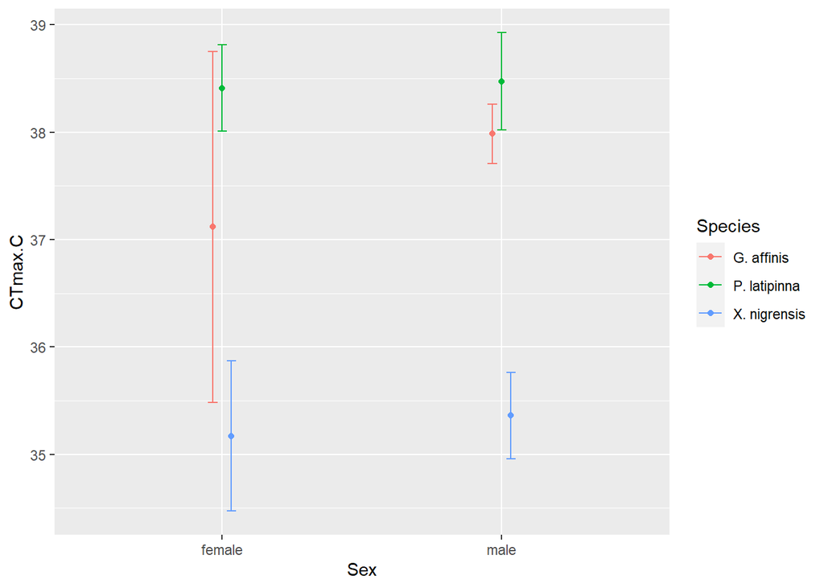

```r
library(ggplot2)
## Gives count, mean, standard deviation, standard error of the mean, and confidence interval (default 95%).
##   data: a data frame.
##   measurevar: the name of a column that contains the variable to be summariezed
##   groupvars: a vector containing names of columns that contain grouping variables
##   na.rm: a boolean that indicates whether to ignore NA's
##   conf.interval: the percent range of the confidence interval (default is 95%)
summarySE <- function(data=NULL, measurevar, groupvars=NULL, na.rm=FALSE,
                      conf.interval=.95, .drop=TRUE) {
    library(plyr)

    # New version of length which can handle NA's: if na.rm==T, don't count them
    length2 <- function (x, na.rm=FALSE) {
        if (na.rm) sum(!is.na(x))
        else       length(x)
    }

    # This does the summary. For each group's data frame, return a vector with
    # N, mean, and sd
    datac <- ddply(data, groupvars, .drop=.drop,
      .fun = function(xx, col) {
        c(N    = length2(xx[[col]], na.rm=na.rm),
          mean = mean   (xx[[col]], na.rm=na.rm),
          sd   = sd     (xx[[col]], na.rm=na.rm)
        )
      },
      measurevar
    )

    # Rename the "mean" column
    datac <- rename(datac, c("mean" = measurevar))

    datac$se <- datac$sd / sqrt(datac$N)  # Calculate standard error of the mean

    # Confidence interval multiplier for standard error
    # Calculate t-statistic for confidence interval:
    # e.g., if conf.interval is .95, use .975 (above/below), and use df=N-1
    ciMult <- qt(conf.interval/2 + .5, datac$N-1)
    datac$ci <- datac$se * ciMult

    return(datac)
}


sums.max <- summarySE(rawdata_1, measurevar="CTmax.C", groupvars=c("Sex","Species"))
sums.min <- summarySE(rawdata_1, measurevar="CTmin.C", groupvars=c("Sex","Species"))
sums.tot <- summarySE(rawdata_1, measurevar="T.tot", groupvars=c("Sex","Species"))

pd <- position_dodge(0.1) # move them .05 to the left and right

ggplot(sums.max, aes(x=Sex, y=CTmax.C, colour=Species, group=interaction(Species,Sex))) +
    geom_errorbar(aes(ymin=CTmax.C-ci, ymax=CTmax.C+ci), width=.1, position=pd) +
    geom_line(position=pd) +
    geom_point(position=pd)
```

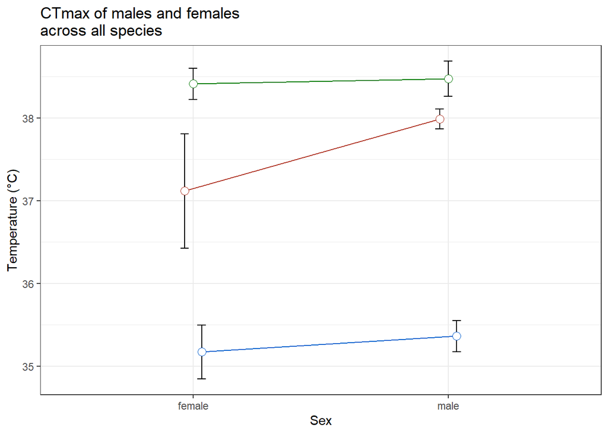

```r
ggplot(sums.max, aes(x=Sex, y=CTmax.C, colour=Species, group=Species)) +
    geom_errorbar(aes(ymin=CTmax.C-se, ymax=CTmax.C+se), colour="black", width=.1, position=pd) +
    geom_line(position=pd) +
    geom_point(position=pd, size=3, shape=21, fill="white") + # 21 is filled circle
    xlab("Sex") +
    ylab("Temperature (°C)") +
    scale_colour_hue(name="Species", breaks=c("G.affinis", "P.latipinna", "X.nigrensis"), labels=c("Mosquitofish", "Sailfin", "Swordtail"), l=40) +
    ggtitle("CTmax of males and females\nacross all species") + theme_bw() + theme(legend.justification=c(1,0), legend.position=c(1,0))
```

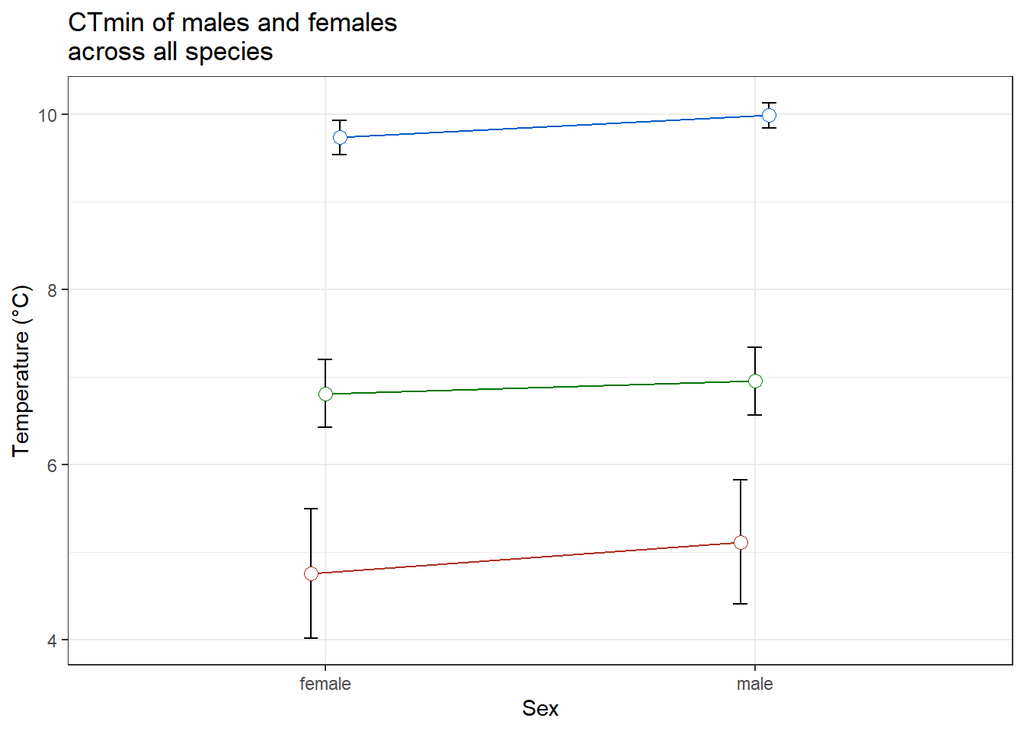

```r
ggplot(sums.min, aes(x=Sex, y=CTmin.C, colour=Species, group=Species)) +
    geom_errorbar(aes(ymin=CTmin.C-se, ymax=CTmin.C+se), colour="black", width=.1, position=pd) +
    geom_line(position=pd) +
    geom_point(position=pd, size=3, shape=21, fill="white") + # 21 is filled circle
    xlab("Sex") +
    ylab("Temperature (°C)") +
    scale_colour_hue(name="Species", breaks=c("G.affinis", "P.latipinna", "X.nigrensis"), labels=c("Mosquitofish", "Sailfin", "Swordtail"), l=40) +
    ggtitle("CTmin of males and females\nacross all species") + theme_bw() + theme(legend.justification=c(1,0), legend.position=c(1,0))
```

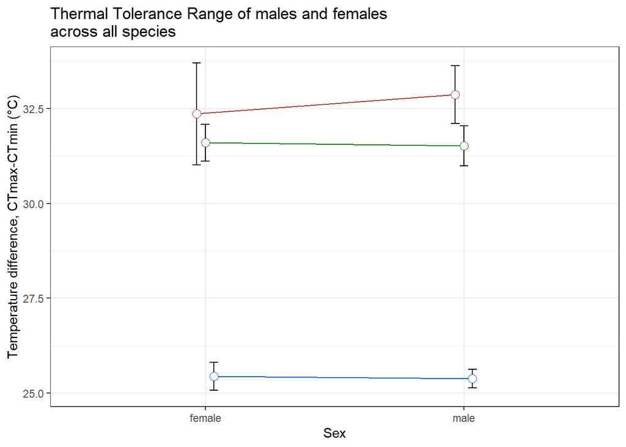

```r
ggplot(sums.tot, aes(x=Sex, y=T.tot, colour=Species, group=Species)) +
    geom_errorbar(aes(ymin=T.tot-se, ymax=T.tot+se), colour="black", width=.1, position=pd) +
    geom_line(position=pd) +
    geom_point(position=pd, size=3, shape=21, fill="white") + # 21 is filled circle
    xlab("Sex") +
    ylab("Temperature difference, CTmax-CTmin (°C)") +
    scale_colour_hue(name="Species", breaks=c("G.affinis", "P.latipinna", "X.nigrensis"), labels=c("Mosquitofish", "Sailfin", "Swordtail"), l=40) +
    ggtitle("Thermal Tolerance Range of males and females\nacross all species") + theme_bw() + theme(legend.justification=c(1,0), legend.position=c(1,0))
```

```r
library(ggpubr)
```

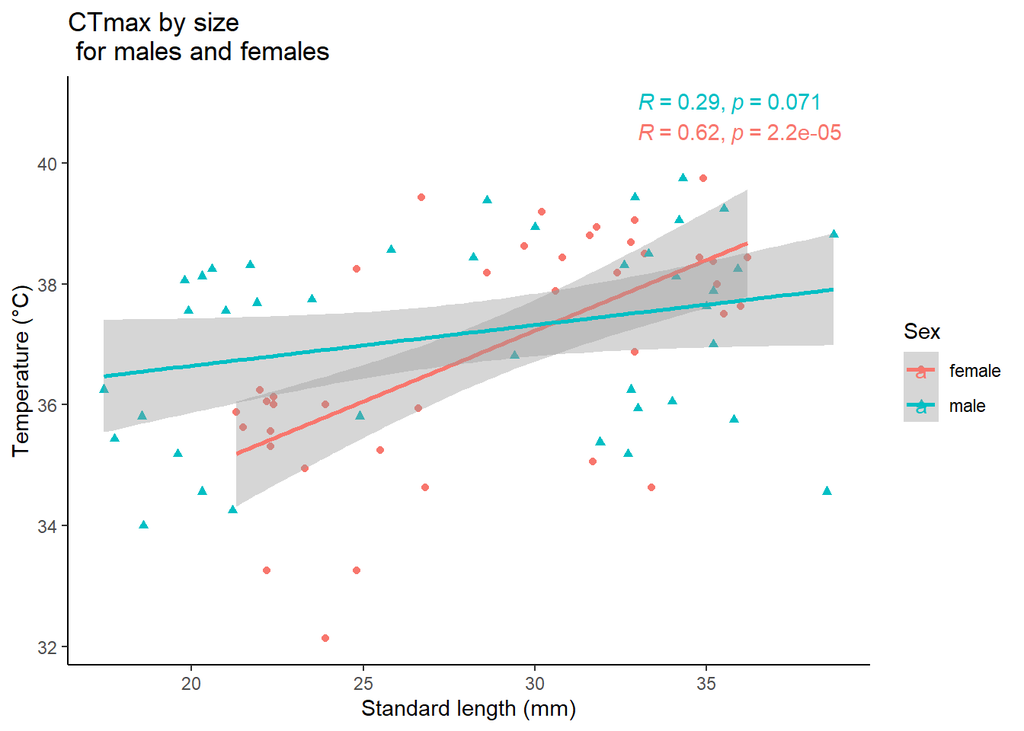

```r
ggplot(rawdata_1, aes(x=Size.mm, y=CTmax.C, color=Sex, shape=Sex)) +
  geom_point() +
  geom_smooth(method=lm, formula = y~x) + stat_cor(label.x = c(33, 33), label.y = c(40.5, 41)) + theme_classic() + labs(title="CTmax by size \n for males and females",
       x="Standard length (mm)", y = "Temperature (°C)")
```

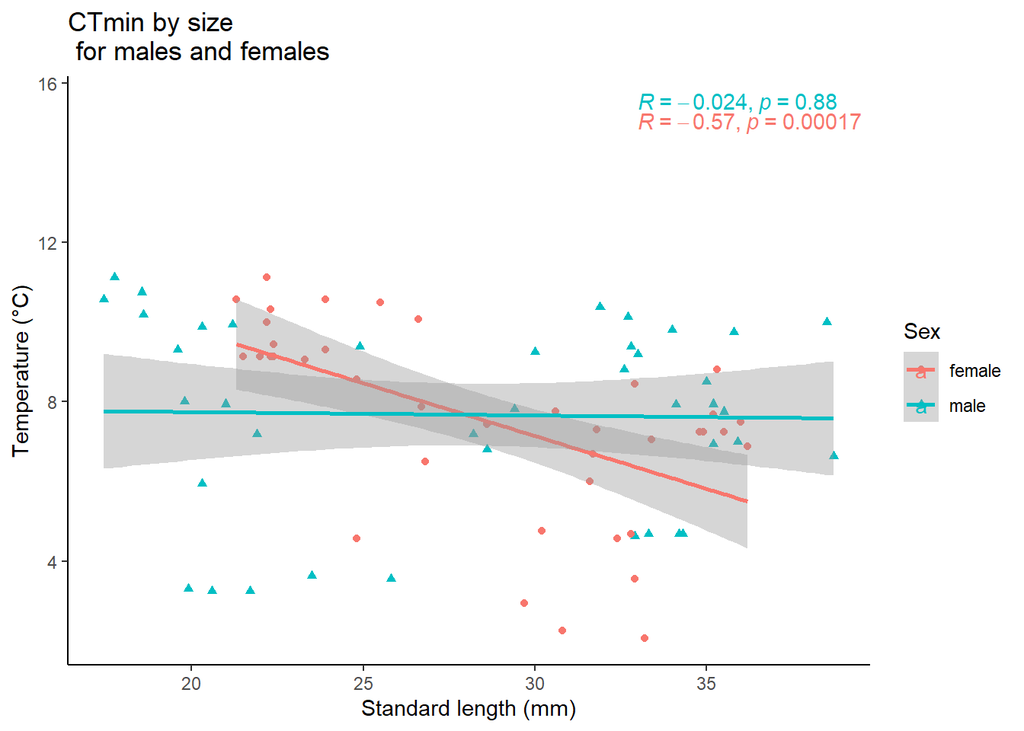

```r
ggplot(rawdata_1, aes(x=Size.mm, y=CTmin.C, color=Sex, shape=Sex)) +
  geom_point() +
  geom_smooth(method=lm, formula = y~x) + stat_cor(label.x = c(33, 33), label.y = c(15, 15.5)) + theme_classic() + labs(title="CTmin by size \n for males and females",
       x="Standard length (mm)", y = "Temperature (°C)")
```

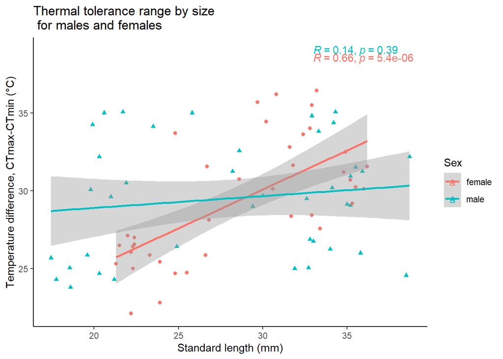

```r
ggplot(rawdata_1, aes(x=Size.mm, y=T.tot, color=Sex, shape=Sex)) +
  geom_point() +
  geom_smooth(method=lm, formula = y~x) + stat_cor(label.x = c(33, 33), label.y = c(38.5, 39)) + theme_classic() + labs(title="Thermal tolerance range by size \n for males and females",
       x="Standard length (mm)", y = "Temperature difference, CTmax-CTmin (°C)")
```

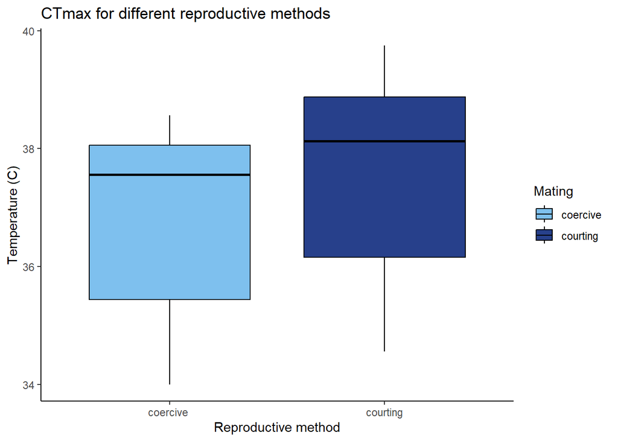

```r
ggplot(subset(rawdata_1, !is.na(Mating)), aes(Mating, CTmax.C, fill=Mating)) + geom_boxplot(color="black") + labs(title="CTmax for different reproductive methods", x ="Reproductive method", y= "Temperature (C)") + theme_classic() + scale_fill_manual(values = c("skyblue2", "royalblue4"))
```

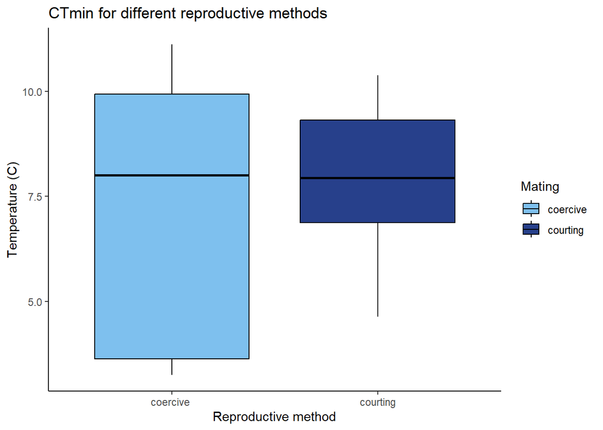

```r
ggplot(subset(rawdata_1, !is.na(Mating)), aes(Mating, CTmin.C, fill=Mating)) + geom_boxplot(color="black") + labs(title="CTmin for different reproductive methods", x ="Reproductive method", y= "Temperature (C)") + theme_classic() + scale_fill_manual(values = c("skyblue2", "royalblue4"))
```

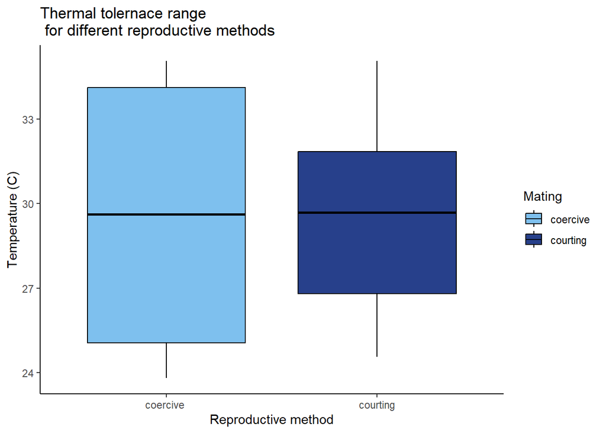

```r
ggplot(subset(rawdata_1, !is.na(Mating)), aes(Mating, T.tot, fill=Mating)) + geom_boxplot(color="black") + labs(title="Thermal tolernace range \n for different reproductive methods", x ="Reproductive method", y= "Temperature (C)") + theme_classic() + scale_fill_manual(values = c("skyblue2", "royalblue4"))
```

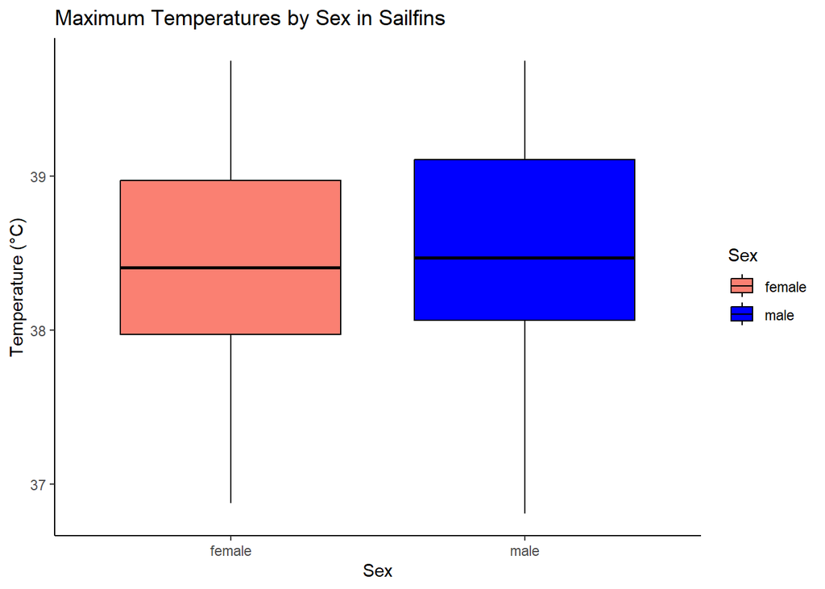

```r
#male v female max temp in sailfin
sailfin_boxplot1 <- ggplot(data = sailfin_1,
                           aes(x = Sex,
                               y = CTmax.C,
                               fill = Sex)) +
  geom_boxplot(color = "black") +
  labs(
    title = "Maximum Temperatures by Sex in Sailfins",
    x = "Sex",
    y = "Temperature (°C)"
  ) +
  theme_classic() +
  scale_fill_manual(values = c("salmon", "blue"))


print(sailfin_boxplot1)
```

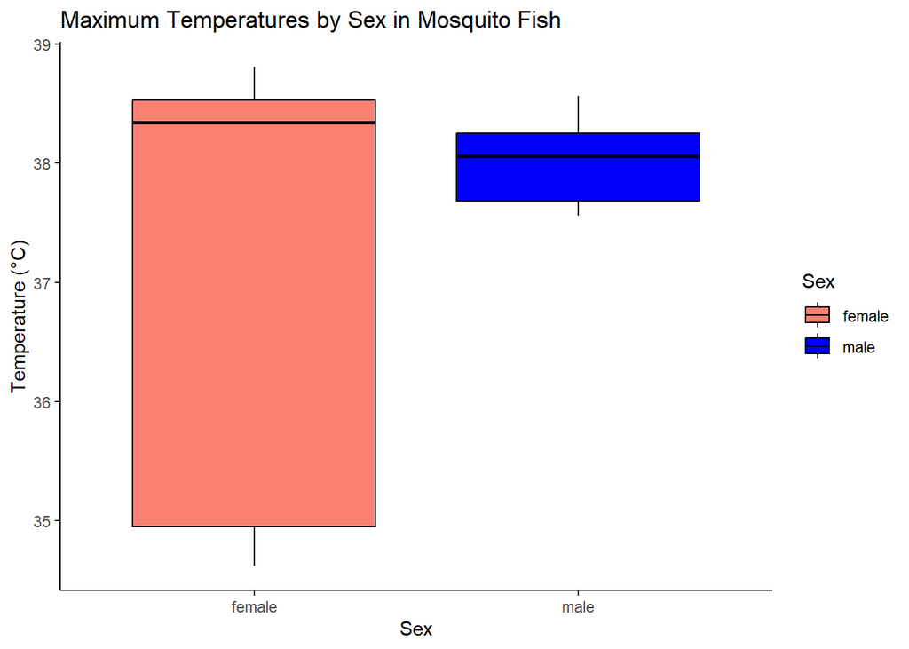

```r
#male v female max temp in mosquitofish
mosquito_boxplot1 <- ggplot(data = mosquito_1,
                           aes(x = Sex,
                               y = CTmax.C,
                               fill = Sex)) +
  geom_boxplot(color = "black") +
  labs(
    title = "Maximum Temperatures by Sex in Mosquito Fish",
    x = "Sex",
    y = "Temperature (°C)"
  ) +
  theme_classic() +
  scale_fill_manual(values = c("salmon", "blue"))

print(mosquito_boxplot1)
```

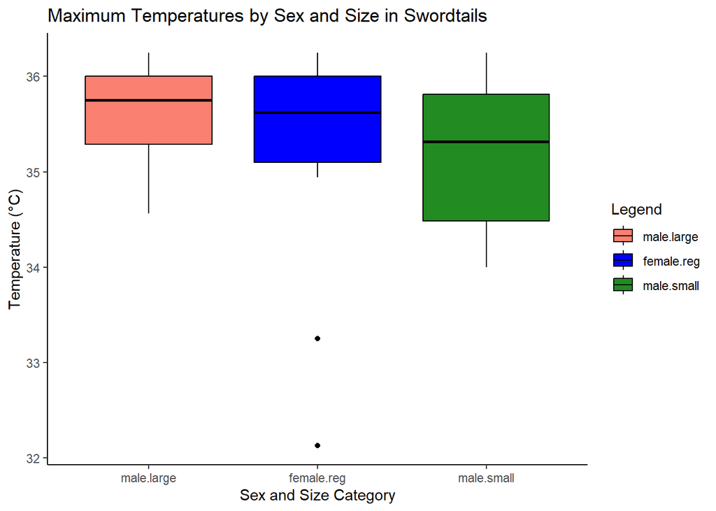

```r
#male v female max temp in swordtail (might want to either create another graph distinguishing between small and large males or just add size category as a shape difference)
swordtail_boxplot4 <- ggplot(data = swordtail_1,
                             aes(x = interaction(Sex, Size.cat),
                                 y = CTmax.C,
                                 fill = interaction(Sex, Size.cat))) +
  geom_boxplot(color = "black") +
  labs(
    title = "Maximum Temperatures by Sex and Size in Swordtails",
    x = "Sex and Size Category",
    y = "Temperature (°C)",
    fill = "Legend"
  ) +
  theme_classic() +
  scale_fill_manual(values = c("salmon", "blue", "forestgreen"))

print(swordtail_boxplot4)
```

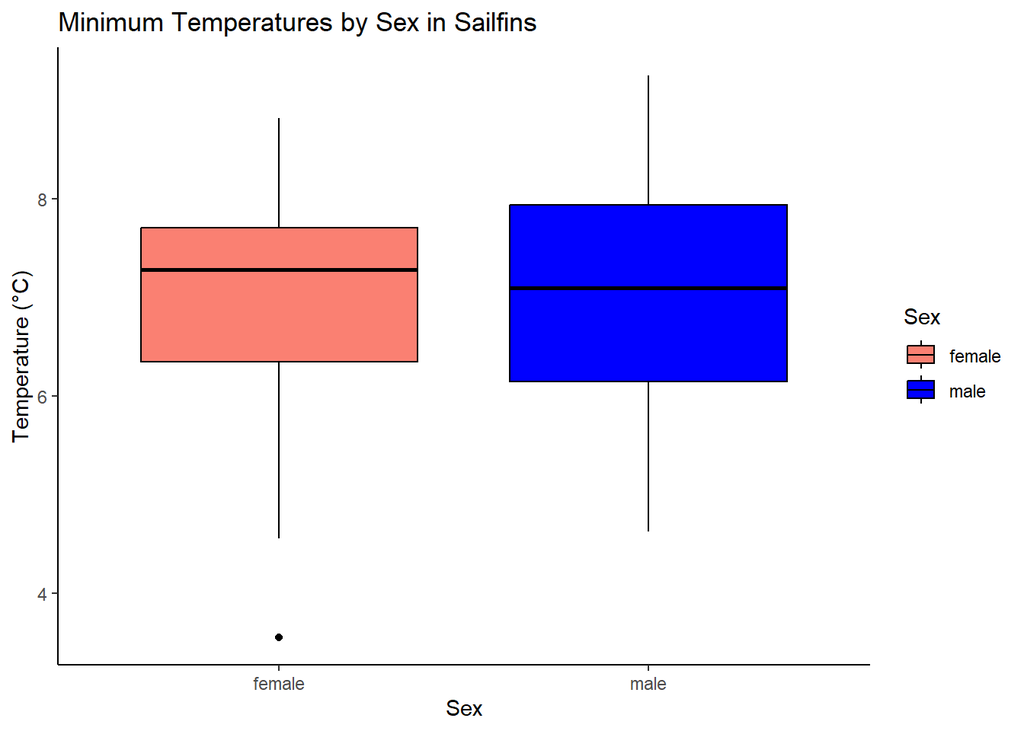

```r
#male v female min temp in sailfin
sailfin_boxplot2 <- ggplot(data = sailfin_1,
                           aes(x = Sex,
                               y = CTmin.C,
                               fill = Sex)) +
  geom_boxplot(color = "black") +
  labs(
    title = "Minimum Temperatures by Sex in Sailfins",
    x = "Sex",
    y = "Temperature (°C)"
  ) +
  theme_classic() +
  scale_fill_manual(values = c("salmon", "blue"))

print(sailfin_boxplot2)
```

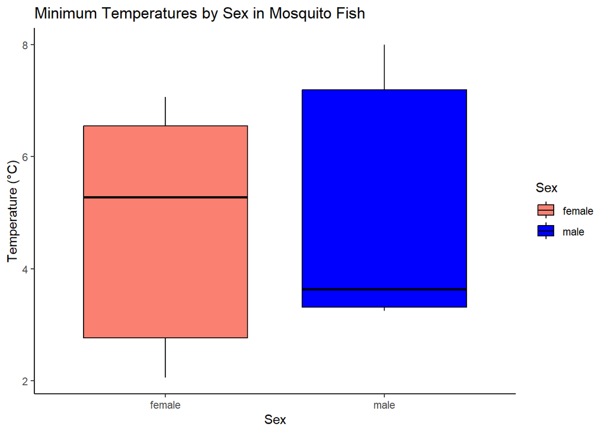

```r
#male v female min temp in mosquitofish
mosquito_boxplot2 <- ggplot(data = mosquito_1,
                           aes(x = Sex,
                               y = CTmin.C,
                               fill = Sex)) +
  geom_boxplot(color = "black") +
  labs(
    title = "Minimum Temperatures by Sex in Mosquito Fish",
    x = "Sex",
    y = "Temperature (°C)"
  ) +
  theme_classic() +
  scale_fill_manual(values = c("salmon", "blue"))

print(mosquito_boxplot2)
```

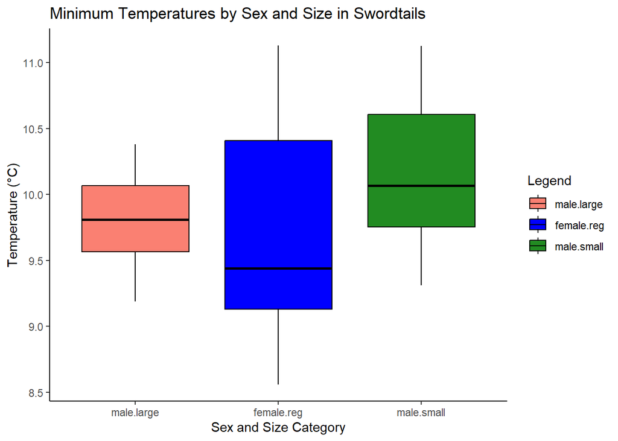

```r
#male v female min temp in swordtail (might want to either create another graph distinguishing between small and large males or just add size category as a shape difference)
swordtail_boxplot5 <- ggplot(data = swordtail_1,
                             aes(x = interaction(Sex, Size.cat),
                                 y = CTmin.C,
                                 fill = interaction(Sex, Size.cat))) +
  geom_boxplot(color = "black") +
  labs(
    title = "Minimum Temperatures by Sex and Size in Swordtails",
    x = "Sex and Size Category",
    y = "Temperature (°C)",
    fill = "Legend"
  ) +
  theme_classic() +
  scale_fill_manual(values = c("salmon", "blue", "forestgreen"))

print(swordtail_boxplot5)
```

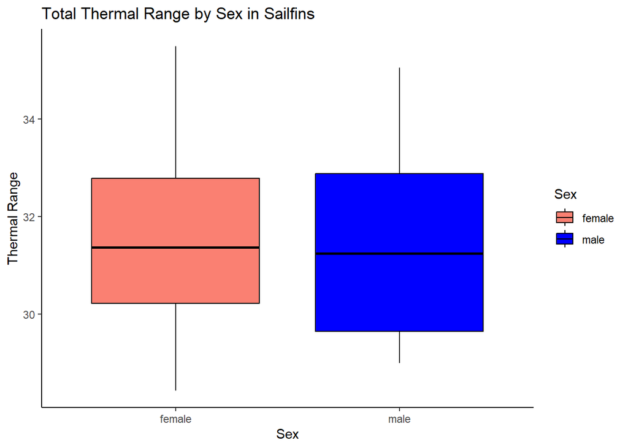

```r
#male v female tot temp in sailfin
sailfin_boxplot3 <- ggplot(data = sailfin_1,
                           aes(x = Sex,
                               y = T.tot,
                               fill = Sex)) +
  geom_boxplot(color = "black") +
  labs(
    title = "Total Thermal Range by Sex in Sailfins",
    x = "Sex",
    y = "Thermal Range"
  ) +
  theme_classic() +
  scale_fill_manual(values = c("salmon", "blue"))

print(sailfin_boxplot3)
```

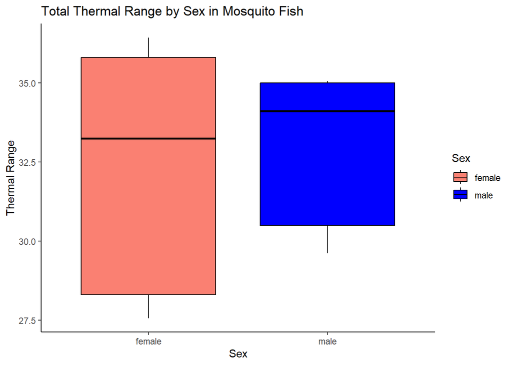

```r
#male v female tot temp in mosquitofish
mosquito_boxplot3 <- ggplot(data = mosquito_1,
                           aes(x = Sex,
                               y = T.tot,
                               fill = Sex)) +
  geom_boxplot(color = "black") +
  labs(
    title = "Total Thermal Range by Sex in Mosquito Fish",
    x = "Sex",
    y = "Thermal Range"
  ) +
  theme_classic() +
  scale_fill_manual(values = c("salmon", "blue"))

print(mosquito_boxplot3)
```

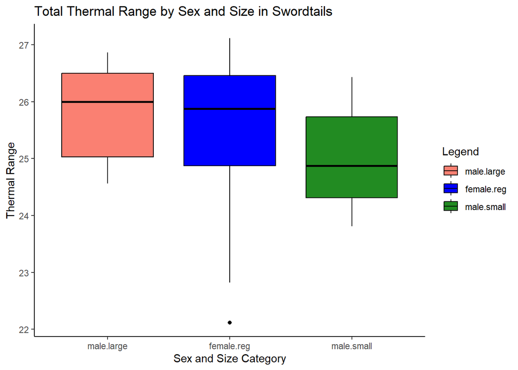

```r
#male v female tot temp in swordtail (might want to either create another graph distinguishing between small and large males or just add size category as a shape difference)
swordtail_boxplot6 <- ggplot(data = swordtail_1,
                             aes(x = interaction(Sex, Size.cat),
                                 y = T.tot,
                                 fill = interaction(Sex, Size.cat))) +
  geom_boxplot(color = "black") +
  labs(
    title = "Total Thermal Range by Sex and Size in Swordtails",
    x = "Sex and Size Category",
    y = "Thermal Range",
    fill = "Legend"
  ) +
  theme_classic() +
  scale_fill_manual(values = c("salmon", "blue", "forestgreen"))

print(swordtail_boxplot6)
```

```r
#male max and min temp across species
#??


#female max and min temp across species



#courting v coercive max temp across species

#courting v coercive min temp across species

#courting v coercive tot temp across species



#courting v coercive max temp within swordtail only

#courting v coercive min temp within swordtail only

#courting v coercive tot temp within swordtail only


#max temp by size (might want to create one general graph and then another where it creates two lines for sex)

#min temp by size (might want to create one general graph and then another where it creates two lines for sex)

#tot temp by size (might want to create one general graph and then another where it creates two lines for sex)
```

# Other

Sooooo it could be that weight is actually a bigger factor than their length. Unfortunately, we only have average weights (so average male and average female weights per species). We can’t connect them to particular individuals, so we can’t use this factor the same as we’ve done above. Tbh not 100% sure what to do here… may be something you just talk about as obvious other contributors to the differences/future studies type thing.